# Statistical analysis of the effect of environmental variables on abundance of flounder

Olga Lyashevska

2024-10-31

```r
# load packages
packages <- c("ggplot2", "MASS", "rmarkdown", "tinytex", "reshape2", "glmmTMB", "DHARMa", "emmeans")
lapply(packages, library, character.only = TRUE)
```

[output not shown]

[output not shown]

```r
knitr::opts_chunk$set(fig.path = "figure/", dev = "png")
set.seed(123)
```

```r
# R version
R.version$version.string
```

```
## [1] "R version 4.4.1 (2024-06-14)"
```

```r
# glmmTMB version
packageVersion("glmmTMB")
```

```
## [1] '1.1.10'
```

# Data preparation and exploration

```r
# load data
df <- read.csv("data.csv")
# describe data
colnames(df)
```

```
##  [1] "site"        "net"         "year"        "lat"         "long"
##  [6] "distshore"   "trawl"       "area"        "chlorophyll" "tempavg"
## [11] "tempstdev"   "sal"         "bod"         "nh3"         "po4"
## [16] "depth"       "nflounder"
```

```r
dim(df)
```

```
## [1] 2763   17
```

```r
df[c("net", "site")]<-lapply(df[c("net", "site")], factor)
summary(df)
```

```
##                               site        net            year
##  Suir Estuary                   : 183   BS  :1264   Min.   :2001
##  Shannon Estuary, Lower         : 163   BT  : 672   1st Qu.:2008
##  Boyne                          : 154   Fyke: 827   Median :2010
##  Barrow Suir Nore Estuary       : 144               Mean   :2011
##  Gweebarra Estuary              : 143               3rd Qu.:2015
##  Barrow Nore Suir Estuary, Upper: 106               Max.   :2019
##  (Other)                        :1870
##       lat             long          distshore           trawl
##  Min.   :51.48   Min.   :-9.966   Min.   :   0.00   Min.   :   0.00
##  1st Qu.:52.28   1st Qu.:-9.074   1st Qu.:  13.90   1st Qu.:   0.00
##  Median :52.66   Median :-8.252   Median :  45.71   Median :   0.00
##  Mean   :52.98   Mean   :-8.025   Mean   : 171.84   Mean   :  32.82
##  3rd Qu.:53.72   3rd Qu.:-6.956   3rd Qu.: 168.15   3rd Qu.:   0.00
##  Max.   :55.09   Max.   :-6.033   Max.   :3097.40   Max.   :1210.00
##
##       area           chlorophyll        tempavg         tempstdev
##  Min.   :  0.0832   Min.   :  1.50   Min.   : 7.305   Min.   :0.04534
##  1st Qu.:  3.0464   1st Qu.:  7.40   1st Qu.:12.773   1st Qu.:3.21952
##  Median :  6.7854   Median : 18.00   Median :13.558   Median :3.90394
##  Mean   : 25.8178   Mean   : 37.57   Mean   :13.480   Mean   :3.75874
##  3rd Qu.: 12.2295   3rd Qu.: 50.30   3rd Qu.:14.455   3rd Qu.:4.54526
##  Max.   :489.4254   Max.   :444.00   Max.   :18.691   Max.   :7.04075
##
##       sal              bod             nh3               po4
##  Min.   : 4.878   Min.   :0.688   Min.   :0.01500   Min.   : 7.909
##  1st Qu.: 7.840   1st Qu.:1.149   1st Qu.:0.04100   1st Qu.:15.595
##  Median :15.609   Median :1.529   Median :0.04600   Median :31.276
##  Mean   :15.511   Mean   :1.522   Mean   :0.06381   Mean   :28.421
##  3rd Qu.:22.959   3rd Qu.:1.629   3rd Qu.:0.07000   3rd Qu.:38.396
##  Max.   :33.047   Max.   :3.825   Max.   :0.17300   Max.   :83.600
##
##      depth         nflounder
##  Min.   :0.700   Min.   :  0.000
##  1st Qu.:2.500   1st Qu.:  0.000
##  Median :4.030   Median :  1.000
##  Mean   :4.378   Mean   :  9.205
##  3rd Qu.:6.170   3rd Qu.:  5.000
##  Max.   :8.400   Max.   :435.000
##
```

```r
# Calculate mean and standard deviation for numeric columns
mean_values <- sapply(df[, sapply(df, is.numeric)], mean)
std_values <- sapply(df[, sapply(df, is.numeric)], sd)

# Combine results into a data frame
summary_stats <- data.frame(
  Mean = mean_values,
  Standard_Deviation = std_values
)

# Print the summary statistics
print(summary_stats)
```

```
##                      Mean Standard_Deviation
## year        2010.87441187         4.65085935
## lat           52.98358706         0.93093971
## long          -8.02453685         1.24818573
## distshore    171.84171257       334.01071158
## trawl         32.82193268        96.60925274
## area          25.81780275        64.18144241
## chlorophyll   37.56829533        52.45523916
## tempavg       13.48047165         1.70693002
## tempstdev      3.75873866         1.25207181
## sal           15.51118096         7.57930983
## bod            1.52220485         0.62485133
## nh3            0.06381252         0.03962164
## po4           28.42140210        14.97467194
## depth          4.37798408         2.27491078
## nflounder      9.20521173        28.84766505
```

## Distribution of nflounder

```r
num_zeros <- sum(df$nflounder == 0)
total_entries <- length(df$nflounder)
percentage_zeros <- (num_zeros / total_entries) * 100
percentage_zeros
```

```
## [1] 44.69779
```

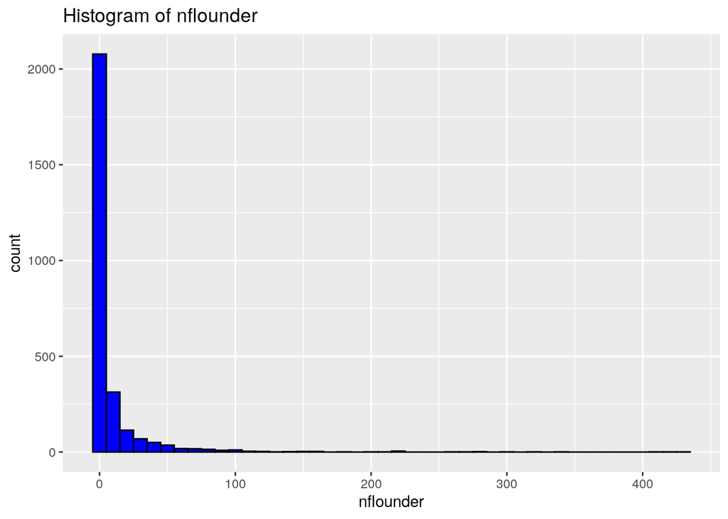

```r
ggplot(df, aes(nflounder)) +
  geom_histogram(binwidth = 10, fill = "blue", color = "black") +
  labs(title = "Histogram of nflounder", x = "nflounder")
```

See how many values fall in each category:

```r
# Define the bin width
bin_width <- 10

# Define the breaks for the bins
breaks <- seq(min(df$nflounder), max(df$nflounder), by = bin_width)

# Divide the data into bins
bins <- cut(df$nflounder, breaks = breaks, include.lowest = TRUE, right = FALSE)

# Count the number of values in each bin
bin_counts <- table(bins)

# Print the bin counts
print(bin_counts)
```

```
## bins
##    [0,10)   [10,20)   [20,30)   [30,40)   [40,50)   [50,60)   [60,70)   [70,80)
##      2245       205        94        57        44        20        19        16
##   [80,90)  [90,100) [100,110) [110,120) [120,130) [130,140) [140,150) [150,160)
##        10        13         7         5         1         2         2         3
## [160,170) [170,180) [180,190) [190,200) [200,210) [210,220) [220,230) [230,240)
##         2         1         0         0         2         1         4         0
## [240,250) [250,260) [260,270) [270,280) [280,290) [290,300) [300,310) [310,320)
##         0         1         0         1         2         0         1         0
## [320,330) [330,340) [340,350) [350,360) [360,370) [370,380) [380,390) [390,400)
##         1         1         0         0         0         0         0         0
## [400,410) [410,420) [420,430]
##         0         2         0
```

Lets truncate values above 100 for modelling convenience.

```r
original_nrow <- nrow(df)
df <- subset(df, nflounder <= 100)
removed_nrow <- original_nrow-nrow(df)
conditional_var <- var(df$nflounder, na.rm=TRUE)
conditional_mean <- mean(df$nflounder, na.rm=TRUE)
```

We removed 39 from 2763. Let’s visualise distribution of nflounder again.

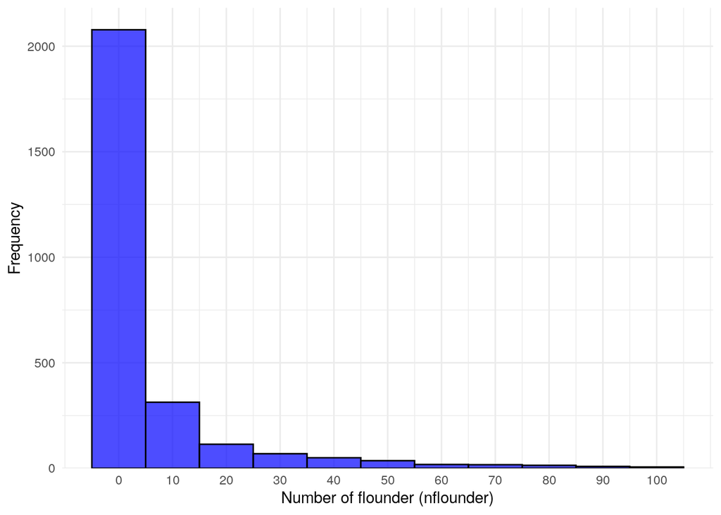

```r
# Load necessary libraries
library(ggplot2)

# Create the histogram
ggplot(df, aes(x = nflounder)) +
  geom_histogram(binwidth = 10, fill = "blue", color = "black", alpha = 0.7) +
  labs(
    x = "Number of flounder (nflounder)",
    y = "Frequency"
  ) +
  theme_minimal() +  # Use a minimal theme for a clean look
  scale_x_continuous(breaks = seq(0, max(df$nflounder, na.rm = TRUE), by = 10)) +  # Customize x-axis breaks
  scale_y_continuous(expand = expansion(mult = c(0, 0.05)))  # Add space at the top of the y-axis
```

As we can see data is still highly overdispersed, the conditional variance (208.0536609) exceeds the conditional mean (6.5179883). In situations like this negative binomial is an appropriate distribution to use.

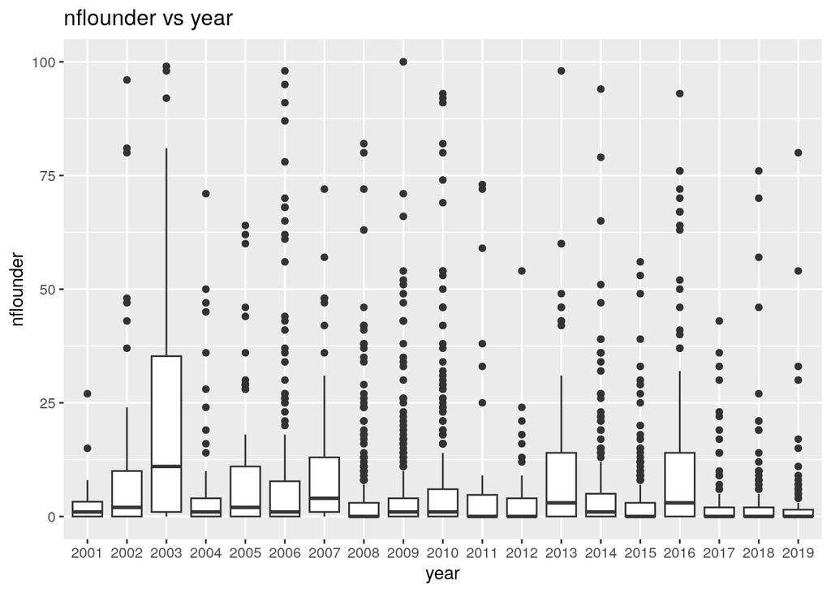

```r
ggplot(df, aes(x = factor(year), y = nflounder)) +
  geom_boxplot() +
  # scale_y_log10() +
  labs(x = "year", y = "nflounder", title = "nflounder vs year")
```

## Correlation analysis

```r
df_numeric <- df[sapply(df, is.numeric)]
cor_matrix <- cor(df_numeric, use = "complete.obs")
print(cor_matrix)
```

```
##                     year           lat        long    distshore        trawl
## year         1.000000000  0.0049817860 -0.06511398  0.088010356 -0.119769828
## lat          0.004981786  1.0000000000  0.04506691 -0.005444478  0.093568489
## long        -0.065113977  0.0450669064  1.00000000 -0.224120769  0.043158598
## distshore    0.088010356 -0.0054444775 -0.22412077  1.000000000  0.144581861
## trawl       -0.119769828  0.0935684891  0.04315860  0.144581861  1.000000000
## area         0.067678064 -0.0007925651 -0.10255599  0.164351090 -0.028732391
## chlorophyll  0.070847279 -0.0322708516  0.14170391  0.020114161  0.003544562
## tempavg      0.093554648 -0.2230929909 -0.04791776  0.084518093 -0.022062488
## tempstdev   -0.156715923 -0.0234881935 -0.05046801  0.096050784  0.025851643
## sal         -0.204827187  0.3989884868 -0.12004630 -0.050253948  0.029244586
## bod         -0.125186675 -0.3154381712  0.25662766 -0.113689564  0.051555411
## nh3         -0.269058242 -0.1454581609  0.24194535 -0.078002487  0.013807491
## po4         -0.159703341 -0.1719509276  0.50093553  0.038484470 -0.036196786
## depth        0.118780600 -0.3806972918  0.20077301  0.045172606 -0.005677570
## nflounder   -0.096151776 -0.1291115877  0.18078237 -0.132022226 -0.002051093
##                      area  chlorophyll     tempavg   tempstdev         sal
## year         0.0676780642  0.070847279  0.09355465 -0.15671592 -0.20482719
## lat         -0.0007925651 -0.032270852 -0.22309299 -0.02348819  0.39898849
## long        -0.1025559916  0.141703905 -0.04791776 -0.05046801 -0.12004630
## distshore    0.1643510905  0.020114161  0.08451809  0.09605078 -0.05025395
## trawl       -0.0287323909  0.003544562 -0.02206249  0.02585164  0.02924459
## area         1.0000000000 -0.007407639 -0.07788099  0.11644657 -0.09950945
## chlorophyll -0.0074076388  1.000000000  0.18577262  0.10878705  0.03726607
## tempavg     -0.0778809900  0.185772616  1.00000000  0.20038897 -0.19076514
## tempstdev    0.1164465703  0.108787049  0.20038897  1.00000000 -0.04111293
## sal         -0.0995094464  0.037266065 -0.19076514 -0.04111293  1.00000000
## bod         -0.1491648863  0.148704747 -0.05496218  0.08648001  0.12076372
## nh3         -0.0667732092 -0.026391337 -0.07254021  0.02594419  0.41822587
## po4          0.1422456757 -0.101320955 -0.02263963  0.05345896 -0.14777738
## depth        0.1227755778 -0.028296778  0.13414873  0.01176289 -0.64814422
## nflounder   -0.0897024377  0.015470871  0.07377867  0.04200609 -0.19505829
##                     bod         nh3         po4       depth    nflounder
## year        -0.12518667 -0.26905824 -0.15970334  0.11878060 -0.096151776
## lat         -0.31543817 -0.14545816 -0.17195093 -0.38069729 -0.129111588
## long         0.25662766  0.24194535  0.50093553  0.20077301  0.180782366
## distshore   -0.11368956 -0.07800249  0.03848447  0.04517261 -0.132022226
## trawl        0.05155541  0.01380749 -0.03619679 -0.00567757 -0.002051093
## area        -0.14916489 -0.06677321  0.14224568  0.12277558 -0.089702438
## chlorophyll  0.14870475 -0.02639134 -0.10132096 -0.02829678  0.015470871
## tempavg     -0.05496218 -0.07254021 -0.02263963  0.13414873  0.073778667
## tempstdev    0.08648001  0.02594419  0.05345896  0.01176289  0.042006088
## sal          0.12076372  0.41822587 -0.14777738 -0.64814422 -0.195058290
## bod          1.00000000  0.42517649  0.35803600 -0.12377171  0.085604235
## nh3          0.42517649  1.00000000  0.48816749 -0.37503797 -0.015704750
## po4          0.35803600  0.48816749  1.00000000  0.18052167  0.059434892
## depth       -0.12377171 -0.37503797  0.18052167  1.00000000  0.113621304
## nflounder    0.08560423 -0.01570475  0.05943489  0.11362130  1.000000000
```

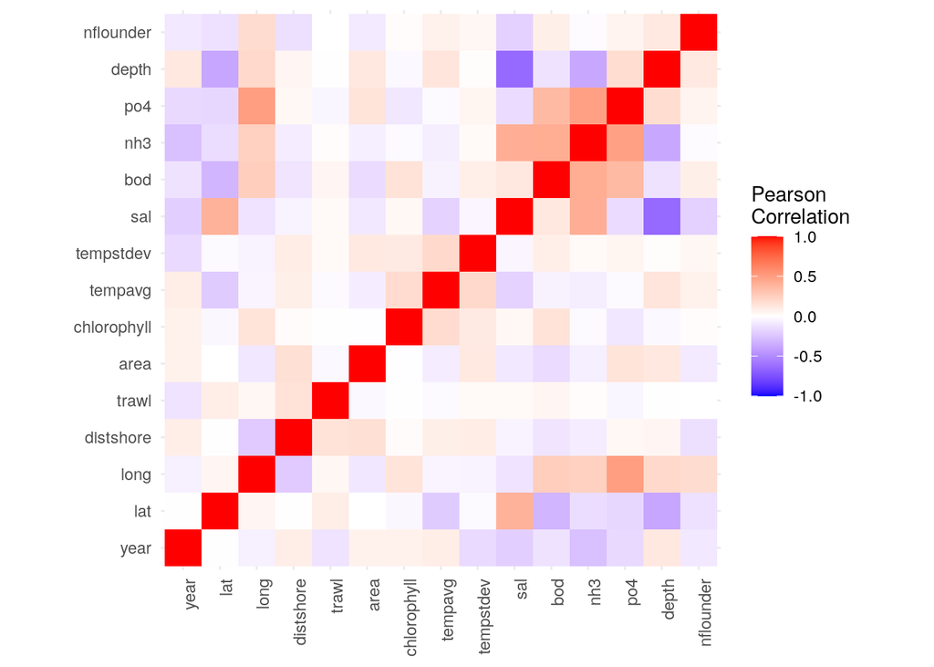

```r
# Melt the correlation matrix into a long format
cor_matrix_melted <- melt(cor_matrix)

# Plot the heatmap using ggplot2
ggplot(data = cor_matrix_melted, aes(x=Var1, y=Var2, fill=value)) +
  geom_tile() +
  scale_fill_gradient2(low = "blue", high = "red", mid = "white",
                       midpoint = 0, limit = c(-1,1), space = "Lab",
                       name="Pearson\nCorrelation") +
  theme_minimal() +
  theme(axis.text.x = element_text(angle = 90, vjust = 1,
                                   size = 9, hjust = 1),
        axis.title.x = element_blank(), # Remove x-axis title
        axis.title.y = element_blank(),) +

  coord_fixed()
```

## Zero-inflation

```r
# Calculate the proportion of values that are 0
zero_proportion <- mean(df$nflounder == 0)
```

The proportion of zeros in nflounder is 0.4533774.

## Scale variables

We shall scale some of the variables to avoid numerical overflow.

```r
var_to_scale <- c("distshore", "area","chlorophyll")
df[, var_to_scale] <- scale(df[, var_to_scale])
```

Consider discarding some of the variables, e.g. `trawl`, in which the proportion of 0’s (should be NA’s?) 0.8509545.

```r
df <- subset(df, select = -trawl)
```

# Data modelling

## Negative binomial GLM

We fit a negative binomial generalized linear model with log link to the full dataset, excluding site, trawl and net for the moment. This model is useful for count data that exhibit overdispersion (the var exceeds the mean). Let $Y_i$ denote the count response variable for the $i$-th observation. The negative binomial distribution for $Y_i$ is parameterised by the mean $\lambda_i$ and the dispersion parameter $\theta$:

$$Y_i \sim \text{NB}(\lambda_i, \theta)$$

where the probability mass function is given by:

$$P(Y_i = k) = \binom{k + \theta - 1}{k} \left( \frac{\theta}{\theta +
\lambda_i} \right)^\theta \left( \frac{\lambda_i}{\theta + \lambda_i}
\right)^k, \quad k = 0, 1, 2, \ldots$$

### Log Link Function

The relationship between the mean $\lambda_i$ and the explanatory variables $\mathbf{X}_i$ is modeled using a log link function:

$$\log(\lambda_i) = \mathbf{X}_i \boldsymbol{\beta}$$

### Linear Predictor

The linear predictor is given:
$$\eta_i = \mathbf{X}_i \boldsymbol{\beta}$$
where $\eta_i = \log(\lambda_i)$. Therefore, the model can be rewritten as:

$$\lambda_i = \exp(\mathbf{X}_i \boldsymbol{\beta})$$

```r
m.glmm.fixed <- glmmTMB(
  nflounder ~ year + lat + long + distshore + area + chlorophyll + tempavg + tempstdev + sal + bod + nh3 + po4 + depth,
  data = df,
  family = nbinom2()
)
summary(m.glmm.fixed)
```

```
##  Family: nbinom2  ( log )
## Formula:
## nflounder ~ year + lat + long + distshore + area + chlorophyll +
##     tempavg + tempstdev + sal + bod + nh3 + po4 + depth
## Data: df
##
##      AIC      BIC   logLik deviance df.resid
##  12986.0  13074.7  -6478.0  12956.0     2709
##
##
## Dispersion parameter for nbinom2 family (): 0.275
##
## Conditional model:
##               Estimate Std. Error z value Pr(>|z|)
## (Intercept) 142.085983  18.135502   7.835 4.70e-15 ***
## year         -0.067561   0.008911  -7.582 3.42e-14 ***
## lat          -0.031889   0.069301  -0.460  0.64541
## long          0.264338   0.045712   5.783 7.35e-09 ***
## distshore    -0.337031   0.039239  -8.589  < 2e-16 ***
## area         -0.086590   0.034720  -2.494  0.01263 *
## chlorophyll  -0.049502   0.043955  -1.126  0.26008
## tempavg       0.041370   0.024032   1.721  0.08516 .
## tempstdev     0.071309   0.031546   2.260  0.02379 *
## sal          -0.095546   0.010504  -9.096  < 2e-16 ***
## bod           0.075791   0.079467   0.954  0.34021
## nh3           4.690307   2.031163   2.309  0.02093 *
## po4          -0.009337   0.004179  -2.234  0.02546 *
## depth        -0.078342   0.028648  -2.735  0.00624 **
## ---
## Signif. codes:  0 '***' 0.001 '**' 0.01 '*' 0.05 '.' 0.1 ' ' 1
```

## Negative Binomial GLMM

Lets add random effect of site and net to the best model. This is an additional term that accounts for unobserved heterogeneity in the data. Random effects are used when data are collected in clusters or groups, and there may be variability between these groups that is not captured by the observed explanatory variables.

### Random Effects

The random effects $u_j$ are assumed to follow a normal distribution with mean zero and variance $\sigma^2_u$:

$$u_j \sim \mathcal{N}(0, \sigma^2_u)$$

### Linear Predictor

The linear predictor is given by:

$$\eta_{ij} = \mathbf{X}_{ij} \boldsymbol{\beta} + u_j$$

where $\eta_{ij} = \log(\lambda_{ij})$. Therefore, the model can be rewritten as:

$$\lambda_{ij} = \exp(\mathbf{X}_{ij} \boldsymbol{\beta} + u_j)$$

```r
# a model of crossed random effects (site and net)
m.glmm.random1 <- glmmTMB(
  nflounder ~ year + lat + long + distshore + area + chlorophyll + tempavg + tempstdev + sal + bod + nh3 + po4 + depth + (1 | site) + (1 | net),
  data = df,
  family = nbinom2()
)
summary(m.glmm.random1)
```

```
##  Family: nbinom2  ( log )
## Formula:
## nflounder ~ year + lat + long + distshore + area + chlorophyll +
##     tempavg + tempstdev + sal + bod + nh3 + po4 + depth + (1 |
##     site) + (1 | net)
## Data: df
##
##      AIC      BIC   logLik deviance df.resid
##  12633.4  12733.9  -6299.7  12599.4     2707
##
## Random effects:
##
## Conditional model:
##  Groups Name        Variance  Std.Dev.
##  site   (Intercept) 1.086e+00 1.0421893
##  net    (Intercept) 1.813e-08 0.0001346
## Number of obs: 2724, groups:  site, 74; net, 3
##
## Dispersion parameter for nbinom2 family (): 0.356
##
## Conditional model:
##               Estimate Std. Error z value Pr(>|z|)
## (Intercept) 146.856572  22.283365   6.590 4.39e-11 ***
## year         -0.079193   0.009943  -7.965 1.66e-15 ***
## lat           0.297084   0.177035   1.678   0.0933 .
## long          0.268307   0.133346   2.012   0.0442 *
## distshore    -0.340952   0.052580  -6.484 8.91e-11 ***
## area          0.010225   0.045513   0.225   0.8222
## chlorophyll  -0.117903   0.045901  -2.569   0.0102 *
## tempavg       0.054199   0.025686   2.110   0.0349 *
## tempstdev     0.043631   0.036127   1.208   0.2272
## sal          -0.092916   0.021349  -4.352 1.35e-05 ***
## bod           0.462236   0.242099   1.909   0.0562 .
## nh3          -4.194333   4.324354  -0.970   0.3321
## po4           0.014944   0.011991   1.246   0.2127
## depth        -0.083901   0.084408  -0.994   0.3202
## ---
## Signif. codes:  0 '***' 0.001 '**' 0.01 '*' 0.05 '.' 0.1 ' ' 1
```

```r
# alternatively we consider a model of nested random effects (net within a site since nets were reused across sites)

m.glmm.random2 <- glmmTMB(
    nflounder ~ year + lat + long + distshore + area + chlorophyll + tempavg + tempstdev + sal + bod + nh3 + po4 + depth + (1 | site/net),
    data = df,
    family = nbinom2()
)
summary(m.glmm.random2)
```

```
##  Family: nbinom2  ( log )
## Formula:
## nflounder ~ year + lat + long + distshore + area + chlorophyll +
##     tempavg + tempstdev + sal + bod + nh3 + po4 + depth + (1 |      site/net)
## Data: df
##
##      AIC      BIC   logLik deviance df.resid
##  12620.4  12720.9  -6293.2  12586.4     2707
##
## Random effects:
##
## Conditional model:
##  Groups   Name        Variance Std.Dev.
##  net:site (Intercept) 0.1387   0.3724
##  site     (Intercept) 0.9891   0.9945
## Number of obs: 2724, groups:  net:site, 191; site, 74
##
## Dispersion parameter for nbinom2 family (): 0.367
##
## Conditional model:
##               Estimate Std. Error z value Pr(>|z|)
## (Intercept) 143.642489  22.690961   6.330 2.45e-10 ***
## year         -0.077686   0.010172  -7.637 2.22e-14 ***
## lat           0.302926   0.174863   1.732   0.0832 .
## long          0.278606   0.131623   2.117   0.0343 *
## distshore    -0.319119   0.053400  -5.976 2.29e-09 ***
## area         -0.007699   0.046434  -0.166   0.8683
## chlorophyll  -0.098694   0.046527  -2.121   0.0339 *
## tempavg       0.049323   0.025896   1.905   0.0568 .
## tempstdev     0.051795   0.036576   1.416   0.1567
## sal          -0.096830   0.021197  -4.568 4.92e-06 ***
## bod           0.433694   0.238992   1.815   0.0696 .
## nh3          -3.737041   4.264675  -0.876   0.3809
## po4           0.015004   0.011836   1.268   0.2049
## depth        -0.075507   0.083328  -0.906   0.3649
## ---
## Signif. codes:  0 '***' 0.001 '**' 0.01 '*' 0.05 '.' 0.1 ' ' 1
```

```r
# year|site for a model with random variation in slopes through years across sites
m.glmm.random3 <- glmmTMB(
    nflounder ~ lat + long + distshore + area + chlorophyll + tempavg + tempstdev + sal + bod + nh3 + po4 + depth + (year | site) + (1|net),
    data = df,
    family = nbinom2()
)
summary(m.glmm.random3)
```

```
##  Family: nbinom2  ( log )
## Formula:
## nflounder ~ lat + long + distshore + area + chlorophyll + tempavg +
##     tempstdev + sal + bod + nh3 + po4 + depth + (year | site) +      (1 | net)
## Data: df
##
##      AIC      BIC   logLik deviance df.resid
##  12635.0  12741.3  -6299.5  12599.0     2706
##
## Random effects:
##
## Conditional model:
##  Groups Name        Variance  Std.Dev.  Corr
##  site   (Intercept) 8.495e+04 2.915e+02
##         year        2.104e-02 1.451e-01 -1.00
##  net    (Intercept) 4.652e-08 2.157e-04
## Number of obs: 2724, groups:  site, 74; net, 3
##
## Dispersion parameter for nbinom2 family (): 0.368
##
## Conditional model:
##              Estimate Std. Error z value Pr(>|z|)
## (Intercept) -17.23222   10.24436  -1.682   0.0925 .
## lat           0.38671    0.18179   2.127   0.0334 *
## long          0.20767    0.13643   1.522   0.1280
## distshore    -0.34926    0.05252  -6.650 2.94e-11 ***
## area          0.02208    0.05015   0.440   0.6597
## chlorophyll  -0.10360    0.04803  -2.157   0.0310 *
## tempavg       0.02584    0.02631   0.982   0.3260
## tempstdev     0.04094    0.03928   1.042   0.2973
## sal          -0.09750    0.02211  -4.409 1.04e-05 ***
## bod           0.48615    0.25131   1.934   0.0531 .
## nh3          -4.83216    4.37859  -1.104   0.2698
## po4           0.02072    0.01246   1.663   0.0963 .
## depth        -0.08201    0.08681  -0.945   0.3449
## ---
## Signif. codes:  0 '***' 0.001 '**' 0.01 '*' 0.05 '.' 0.1 ' ' 1
```

Lets compare fixed and random effect models.

```r
anova(m.glmm.fixed, m.glmm.random1, m.glmm.random2, m.glmm.random3)
```

|  | Df | AIC | BIC | logLik | deviance | Chisq | Chi Df | Pr(>Chisq) |
| --- | --- | --- | --- | --- | --- | --- | --- | --- |
| m.glmm.fixed | 15 | 12986.05 | 13074.69 | -6478.023 | 12956.05 | NA | NA | NA |
| m.glmm.random1 | 17 | 12633.39 | 12733.85 | -6299.693 | 12599.39 | 356.66033 | 2 | 3.566104e-78 |
| m.glmm.random2 | 17 | 12620.42 | 12720.89 | -6293.211 | 12586.42 | 12.96329 | 0 | 0.000000e+00 |
| m.glmm.random3 | 18 | 12634.97 | 12741.34 | -6299.484 | 12598.97 | 0.00000 | 1 | 1.000000e+00 |

We choose the model with lowest AIC which is `m.glmm.random2`, a model of nested random effects (net within a site).

## Zero-inflated poisson GLMM

Now lets try a zero-inflated Poisson model with a single zero inflation parameter applying to all observations using ziformula~1.

```r
m.glmm.random.zero <- glmmTMB(
    nflounder ~ year + lat + long + distshore + area + chlorophyll + tempavg + tempstdev + sal + bod + nh3 + po4 + depth + (1 | site/net),
    data = df,
    ziformula=~1,
    family = poisson()
)
summary(m.glmm.random.zero)
```

```
##  Family: poisson  ( log )
## Formula:
## nflounder ~ year + lat + long + distshore + area + chlorophyll +
##     tempavg + tempstdev + sal + bod + nh3 + po4 + depth + (1 |      site/net)
## Zero inflation:             ~1
## Data: df
##
##      AIC      BIC   logLik deviance df.resid
##  26443.9  26544.3 -13204.9  26409.9     2707
##
## Random effects:
##
## Conditional model:
##  Groups   Name        Variance Std.Dev.
##  net:site (Intercept)  0.5892  0.7676
##  site     (Intercept) 28.6579  5.3533
## Number of obs: 2724, groups:  net:site, 191; site, 74
##
## Conditional model:
##               Estimate Std. Error z value Pr(>|z|)
## (Intercept) -2.548e+02  1.552e+01 -16.415  < 2e-16 ***
## year        -4.676e-02  2.152e-03 -21.729  < 2e-16 ***
## lat          6.265e+00  2.798e-01  22.390  < 2e-16 ***
## long        -1.380e+00  1.405e-01  -9.820  < 2e-16 ***
## distshore   -2.792e-01  2.195e-02 -12.718  < 2e-16 ***
## area         9.999e-03  1.305e-02   0.766  0.44351
## chlorophyll -2.942e-02  9.872e-03  -2.980  0.00288 **
## tempavg      4.913e-02  6.204e-03   7.918 2.40e-15 ***
## tempstdev   -1.869e-02  7.958e-03  -2.349  0.01882 *
## sal         -1.532e-01  8.080e-02  -1.896  0.05792 .
## bod          4.488e+00  1.013e+00   4.430 9.44e-06 ***
## nh3         -2.895e+01  1.053e+01  -2.749  0.00598 **
## po4          6.538e-02  5.017e-02   1.303  0.19253
## depth        5.195e-01  3.564e-01   1.458  0.14497
## ---
## Signif. codes:  0 '***' 0.001 '**' 0.01 '*' 0.05 '.' 0.1 ' ' 1
##
## Zero-inflation model:
##             Estimate Std. Error z value Pr(>|z|)
## (Intercept) -0.57605    0.04689  -12.28   <2e-16 ***
## ---
## Signif. codes:  0 '***' 0.001 '**' 0.01 '*' 0.05 '.' 0.1 ' ' 1
```

This model has higher AIC, hence we prefer binomial models.

## Truncated Negative Binomial GLMM (Hurdle Model).

In contrast to zero-inflated models, hurdle models treat zero-count and nonzero outcomes as two completely separate categories, rather than treating the zero-count outcomes as a mixture of structural and sampling zeros.

```r
m.glmm.random2.hurdle <- update (m.glmm.random2,
                                 data=df,
                                 ziformula=~.,
                                 family=truncated_nbinom2())
summary(m.glmm.random2.hurdle)
```

```
##  Family: truncated_nbinom2  ( log )
## Formula:
## nflounder ~ year + lat + long + distshore + area + chlorophyll +
##     tempavg + tempstdev + sal + bod + nh3 + po4 + depth + (1 |      site/net)
## Zero inflation:             ~.
## Data: df
##
##      AIC      BIC   logLik deviance df.resid
##  12602.9  12797.9  -6268.4  12536.9     2691
##
## Random effects:
##
## Conditional model:
##  Groups   Name        Variance Std.Dev.
##  net:site (Intercept) 0.08004  0.2829
##  site     (Intercept) 0.70242  0.8381
## Number of obs: 2724, groups:  net:site, 191; site, 74
##
## Zero-inflation model:
##  Groups   Name        Variance Std.Dev.
##  net:site (Intercept) 0.1106   0.3325
##  site     (Intercept) 0.4699   0.6855
## Number of obs: 2724, groups:  net:site, 191; site, 74
##
## Dispersion parameter for truncated_nbinom2 family (): 0.28
##
## Conditional model:
##               Estimate Std. Error z value Pr(>|z|)
## (Intercept)  1.123e+02  2.642e+01   4.252 2.12e-05 ***
## year        -6.124e-02  1.239e-02  -4.945 7.63e-07 ***
## lat          2.450e-01  1.710e-01   1.433 0.151930
## long         8.322e-02  1.251e-01   0.665 0.505776
## distshore   -3.746e-01  7.180e-02  -5.218 1.81e-07 ***
## area        -1.690e-02  5.471e-02  -0.309 0.757388
## chlorophyll -6.165e-02  6.006e-02  -1.026 0.304673
## tempavg      6.412e-02  3.245e-02   1.976 0.048186 *
## tempstdev    4.099e-04  4.514e-02   0.009 0.992755
## sal         -8.562e-02  2.212e-02  -3.871 0.000108 ***
## bod          2.785e-01  2.219e-01   1.255 0.209523
## nh3         -4.264e+00  4.294e+00  -0.993 0.320633
```

[output cut: 8 more lines]

```
## year         7.956e-02  1.234e-02   6.446 1.15e-10 ***
## lat         -3.740e-02  1.371e-01  -0.273 0.785028
## long        -4.484e-01  1.057e-01  -4.243 2.21e-05 ***
## distshore    1.929e-01  5.682e-02   3.394 0.000689 ***
## area        -3.049e-02  5.444e-02  -0.560 0.575442
## chlorophyll  9.591e-02  5.440e-02   1.763 0.077878 .
## tempavg     -2.900e-02  2.948e-02  -0.984 0.325221
## tempstdev   -9.100e-02  4.212e-02  -2.161 0.030731 *
## sal          7.956e-02  1.699e-02   4.683 2.83e-06 ***
## bod         -2.746e-01  1.924e-01  -1.428 0.153394
## nh3          1.106e+00  3.358e+00   0.329 0.741782
## po4         -4.538e-05  9.307e-03  -0.005 0.996109
## depth        1.147e-01  6.511e-02   1.762 0.078125 .
## ---
## Signif. codes:  0 '***' 0.001 '**' 0.01 '*' 0.05 '.' 0.1 ' ' 1
```

Lets compare the models.

```r
anova(m.glmm.random2, m.glmm.random2.hurdle)
```

|  | Df | AIC | BIC | logLik | deviance | Chisq | Chi Df | Pr(>Chisq) |
| --- | --- | --- | --- | --- | --- | --- | --- | --- |
| m.glmm.random2 | 17 | 12620.42 | 12720.89 | -6293.211 | 12586.42 | NA | NA | NA |
| m.glmm.random2.hurdle | 33 | 12602.89 | 12797.92 | -6268.447 | 12536.89 | 49.52772 | 16 | 2.725345e-05 |

Model `m.glmm.random2.hurdle` is significantly better. From now on we continue with the negative binomial GLMM Hurdle model. This model assumes the following:

### Parameterization

Let $Y_{ij}$ denote the count response variable for the $i$-th observation in the $j$-th group or individual. The model is parameterised as follows:

### Link Function

The relationship between the mean count $\lambda_{ij}$ and the predictors $X_{ij}$ is modeled using a log link function:

$$\log(\lambda_{ij}) = X_{ij}\beta + u_j$$

where $X_{ij}$ is a vector of fixed effect predictors, $\beta$ is a vector of fixed effect coefficients, and $u_j$ represents the random effect for the $j$-th group or individual.

### Interpretation

The Negative Binomial GLMM estimates the effects of the predictors on both the count of events and the presence of excess zeros. The fixed effect coefficients ($\beta$) quantify the impact of the predictors on the mean count ($\lambda_{ij}$), while the random effects ($u_j$) capture the variability among groups or individuals.

## Post-model-fitting procedure.

### Residuals

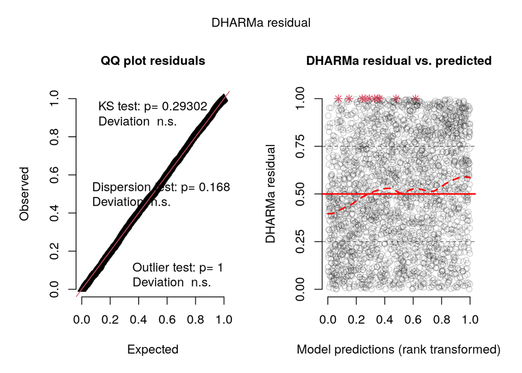

```r
plot(simulateResiduals(m.glmm.random2.hurdle))
```

### Estimated marginal means

Lets consider marginal means between net types.

```r
m.glmm.random2.hurdle.net <- glmmTMB(
    nflounder ~ year + lat + long + distshore + area + chlorophyll + tempavg + tempstdev + sal + bod + nh3 + po4 + depth + net + (1 | site/net),
    data = df,
    ziformula=~.,
    family=truncated_nbinom2()
)
summary(m.glmm.random2.hurdle.net)
```

```
##  Family: truncated_nbinom2  ( log )
## Formula:
## nflounder ~ year + lat + long + distshore + area + chlorophyll +
##     tempavg + tempstdev + sal + bod + nh3 + po4 + depth + net +
##     (1 | site/net)
## Zero inflation:             ~.
## Data: df
##
##      AIC      BIC   logLik deviance df.resid
##  12607.2  12825.8  -6266.6  12533.2     2687
##
## Random effects:
##
## Conditional model:
##  Groups   Name        Variance Std.Dev.
##  net:site (Intercept) 0.07618  0.2760
##  site     (Intercept) 0.70104  0.8373
## Number of obs: 2724, groups:  net:site, 191; site, 74
##
## Zero-inflation model:
##  Groups   Name        Variance Std.Dev.
##  net:site (Intercept) 0.09005  0.3001
##  site     (Intercept) 0.47974  0.6926
## Number of obs: 2724, groups:  net:site, 191; site, 74
##
## Dispersion parameter for truncated_nbinom2 family (): 0.28
##
## Conditional model:
##               Estimate Std. Error z value Pr(>|z|)
## (Intercept)  1.125e+02  2.674e+01   4.208 2.57e-05 ***
## year        -6.130e-02  1.253e-02  -4.893 9.95e-07 ***
## lat          2.436e-01  1.710e-01   1.424 0.154340
## long         8.336e-02  1.250e-01   0.667 0.504755
## distshore   -3.740e-01  7.193e-02  -5.200 2.00e-07 ***
## area        -1.803e-02  5.472e-02  -0.329 0.741826
## chlorophyll -6.042e-02  6.015e-02  -1.005 0.315135
## tempavg      6.471e-02  3.251e-02   1.991 0.046530 *
## tempstdev    6.145e-05  4.511e-02   0.001 0.998913
## sal         -8.518e-02  2.211e-02  -3.852 0.000117 ***
## bod          2.828e-01  2.217e-01   1.276 0.202061
```

[output cut: 13 more lines]

```
## long        -4.529e-01  1.058e-01  -4.280 1.87e-05 ***
## distshore    1.838e-01  5.686e-02   3.232  0.00123 **
## area        -2.822e-02  5.435e-02  -0.519  0.60356
## chlorophyll  9.441e-02  5.436e-02   1.737  0.08240 .
## tempavg     -2.844e-02  2.947e-02  -0.965  0.33439
## tempstdev   -9.572e-02  4.217e-02  -2.270  0.02321 *
## sal          7.959e-02  1.700e-02   4.683 2.83e-06 ***
## bod         -2.858e-01  1.928e-01  -1.482  0.13821
## nh3          1.055e+00  3.363e+00   0.314  0.75369
## po4          7.438e-04  9.325e-03   0.080  0.93642
## depth        1.134e-01  6.514e-02   1.741  0.08175 .
## netBT        2.647e-01  1.396e-01   1.895  0.05804 .
## netFyke      1.037e-01  1.258e-01   0.824  0.40992
## ---
## Signif. codes:  0 '***' 0.001 '**' 0.01 '*' 0.05 '.' 0.1 ' ' 1
```

```r
emmeans(m.glmm.random2.hurdle.net,"net")
```

```
##  net  emmean    SE  df asymp.LCL asymp.UCL
##  BS     1.19 0.167 Inf     0.857      1.51
##  BT     1.16 0.188 Inf     0.793      1.53
##  Fyke   1.24 0.176 Inf     0.891      1.58
##
## Results are given on the log (not the response) scale.
## Confidence level used: 0.95
```

### Variable selection with drop1

Refit the model with various terms dropped.

```r
system.time(m.glmm.random2.hurdle.d1 <- drop1(m.glmm.random2.hurdle,test="Chisq"))
```

```
##    user  system elapsed
## 267.345  12.004 266.007
```

```r
print(m.glmm.random2.hurdle.d1)
```

```
## Single term deletions
##
## Model:
## nflounder ~ year + lat + long + distshore + area + chlorophyll +
##     tempavg + tempstdev + sal + bod + nh3 + po4 + depth + (1 |
##     site/net)
##             Df   AIC    LRT  Pr(>Chi)
## <none>         12603
## year         2 12666 67.016 2.803e-15 ***
## lat          2 12601  2.188 0.3349165
## long         2 12616 16.602 0.0002483 ***
## distshore    2 12636 36.775 1.034e-08 ***
## area         2 12599  0.410 0.8147107
## chlorophyll  2 12603  4.128 0.1269135
## tempavg      2 12604  4.846 0.0886542 .
## tempstdev    2 12604  4.661 0.0972639 .
## sal          2 12632 32.729 7.816e-08 ***
## bod          2 12603  3.686 0.1583137
## nh3          2 12600  1.087 0.5808045
## po4          2 12600  1.307 0.5203431
## depth        2 12603  4.024 0.1337202
## ---
## Signif. codes:  0 '***' 0.001 '**' 0.01 '*' 0.05 '.' 0.1 ' ' 1
```

```r
final <- glmmTMB(nflounder ~ year + lat + long + distshore + chlorophyll + tempavg + tempstdev + sal + depth + (1 | site/net),
    data = df,
    ziformula=~.,
    family=truncated_nbinom2())
summary(final)
```

```
##  Family: truncated_nbinom2  ( log )
## Formula:
## nflounder ~ year + lat + long + distshore + chlorophyll + tempavg +
##     tempstdev + sal + depth + (1 | site/net)
## Zero inflation:             ~.
## Data: df
##
##      AIC      BIC   logLik deviance df.resid
##  12593.0  12740.8  -6271.5  12543.0     2699
##
## Random effects:
##
## Conditional model:
##  Groups   Name        Variance Std.Dev.
##  net:site (Intercept) 0.08427  0.2903
##  site     (Intercept) 0.70174  0.8377
## Number of obs: 2724, groups:  net:site, 191; site, 74
##
## Zero-inflation model:
##  Groups   Name        Variance Std.Dev.
##  net:site (Intercept) 0.1120   0.3347
##  site     (Intercept) 0.4647   0.6817
## Number of obs: 2724, groups:  net:site, 191; site, 74
##
## Dispersion parameter for truncated_nbinom2 family (): 0.278
##
## Conditional model:
##               Estimate Std. Error z value Pr(>|z|)
## (Intercept) 119.527354  25.435578   4.699 2.61e-06 ***
## year         -0.062489   0.012236  -5.107 3.27e-07 ***
## lat           0.182753   0.148231   1.233    0.218
## long          0.170123   0.100641   1.690    0.091 .
## distshore    -0.371930   0.071585  -5.196 2.04e-07 ***
## chlorophyll  -0.063906   0.059707  -1.070    0.284
## tempavg       0.062877   0.032362   1.943    0.052 .
## tempstdev    -0.001606   0.043740  -0.037    0.971
## sal          -0.092118   0.020512  -4.491 7.09e-06 ***
## depth        -0.090804   0.075929  -1.196    0.232
## ---
## Signif. codes:  0 '***' 0.001 '**' 0.01 '*' 0.05 '.' 0.1 ' ' 1
##
## Zero-inflation model:
##               Estimate Std. Error z value Pr(>|z|)
## (Intercept) -164.69953   25.01589  -6.584 4.59e-11 ***
## year           0.07845    0.01216   6.449 1.12e-10 ***
## lat            0.03243    0.11729   0.276 0.782183
## long          -0.48693    0.08346  -5.835 5.39e-09 ***
## distshore      0.19285    0.05665   3.404 0.000663 ***
## chlorophyll    0.08952    0.05390   1.661 0.096736 .
## tempavg       -0.02442    0.02925  -0.835 0.403760
## tempstdev     -0.10104    0.04091  -2.470 0.013511 *
## sal            0.07914    0.01586   4.990 6.05e-07 ***
## depth          0.12938    0.05890   2.197 0.028055 *
## ---
## Signif. codes:  0 '***' 0.001 '**' 0.01 '*' 0.05 '.' 0.1 ' ' 1
```

## Conclusion

The response variable nflounder is modeled using a truncated negative binomial distribution with a log link function (Hurdle).

Truncated Negative Binomial model is a two part model, where the zero-inflation model estimates the presence/absence; the conditional model estimates the abundance.

The predictors in the both parts of the model include year, lat, long, distshore, chlorophyll, tempavg, tempstdev, sal, and depth, along with a random intercept for site/net.

### Random effect

#### Conditional Model:

- net:site Group (Intercept): The variability in the response variable nflounder due to the grouping of nets within sites is relatively low, with a variance of 0.08427 and a standard deviation of 0.2903.
- site Group (Intercept): The variability in nflounder due to different sites is higher compared to the net:site grouping, with a variance of 0.70174 and a standard deviation of 0.8377.

#### Zero-Inflation Model:

net:site Group (Intercept): The variability in the zero-inflation component attributable to the grouping of nets within sites is moderate, with a variance of 0.1120 and a standard deviation of 0.3347. site Group (Intercept): The variability in zero-inflation due to different sites is relatively higher, with a variance of 0.4647 and a standard deviation of 0.6817.

### Fixed Effects

#### Conditional Model:

The predictor year is statistically significant (p < 0.001), with a negative coefficient indicating a decrease in nflounder over time. distshore and salinity also show significance (p < 0.001 and p < 0.05, respectively), with negative coefficients implying a negative association with nflounder. Other predictors such as latitude, longitude, chlorophyll, average temperature, temperature standard deviation, and depth do not show statistically significant associations with nflounder.

## References

Brooks ME, Kristensen K, van Benthem KJ, Magnusson A, Berg CW, Nielsen A, Skaug HJ, Maechler M, Bolker BM (2017). “glmmTMB Balances Speed and Flexibility Among Packages for Zero-inflated Generalized Linear Mixed Modeling.” The R Journal, 9(2), 378–400. doi:10.32614/RJ-2017-066.